# Future Predicted Value

Xuhao Dong

2021-12-05

## Future Predicted Value

Future predicted value is the estimate of how much someone will spend in the future with a company. In this report we calculate FPV for the Wedge in 2015 using data from before that year. Our report has the following sections:

1. Variable selection: In this section we describe the variables that we use in the model.
2. Model formulation: This section describes the model itself.
3. Estimates of model accuracy: We run a quick analysis of model accuracy in the final section.

```
## Package "greybox", v0.6.8 loaded.
```

```
## [1] "owner_sales_by_yearmonth"         "product_description_by_yearmonth"
## [3] "sales_by_date_hour"
```

### Variable Selection

I first created a bound and take the number of row and split into 10/90, then shuffle the dataset and put them into two new dataframe md.train and md.test.

### Model Formulation

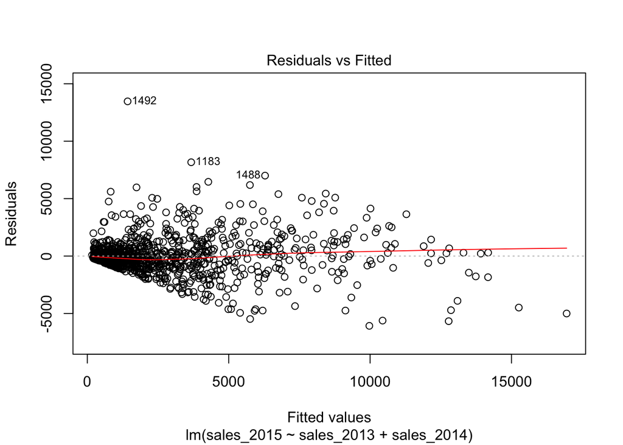

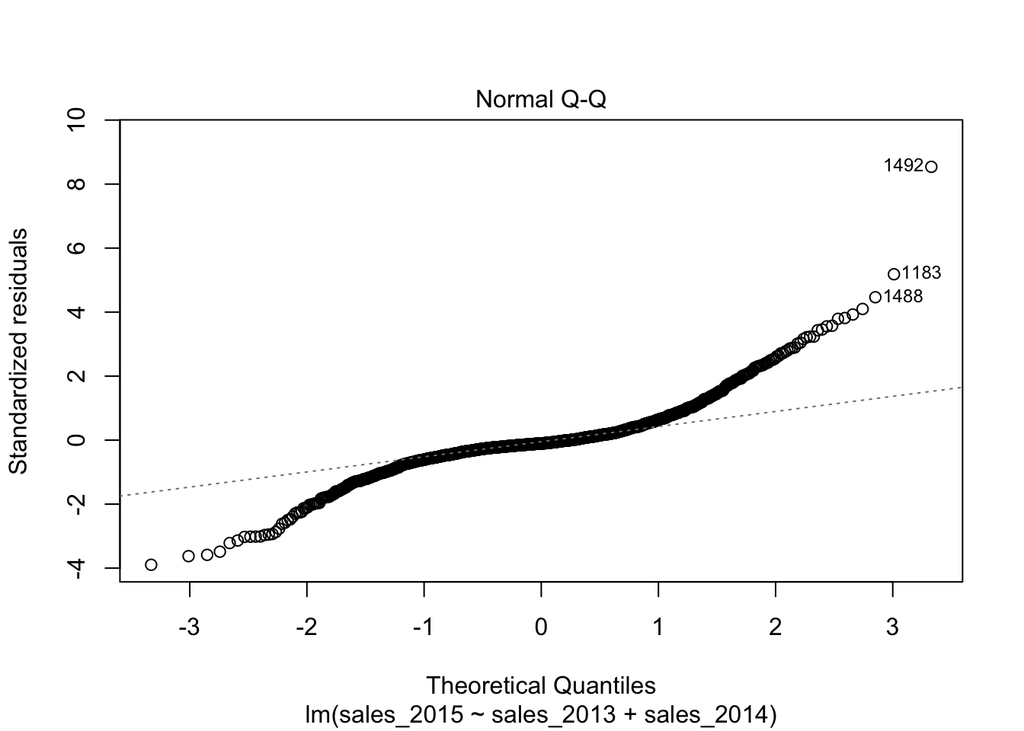

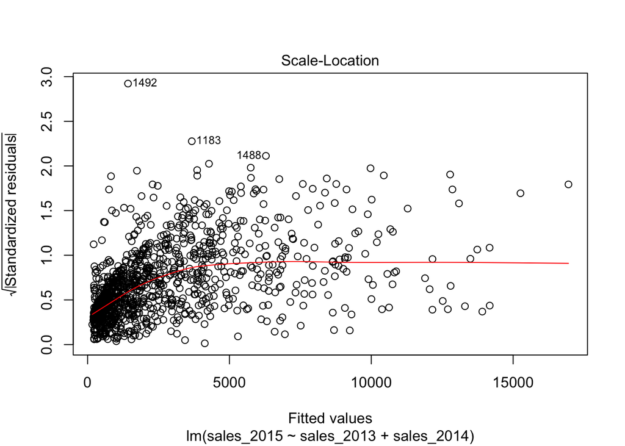

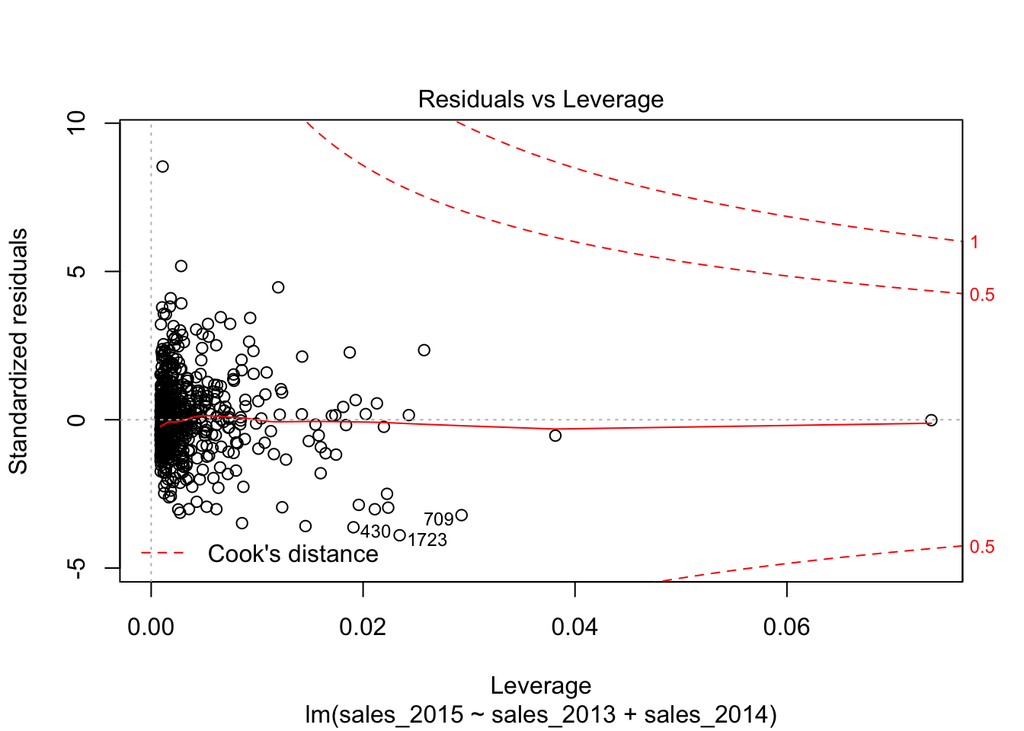

```
## # A tibble: 3 x 5
##   term        estimate std.error statistic   p.value
##   <chr>          <dbl>     <dbl>     <dbl>     <dbl>
## 1 (Intercept) 208.       63.2         3.29 1.02e-  3
## 2 sales_2013   -0.0291    0.0267     -1.09 2.76e-  1
## 3 sales_2014    0.856     0.0276     31.0  1.09e-153
```

```
##
## Call:
## lm(formula = sales_2015 ~ sales_2013 + sales_2014, data = md.train,
##     subset = sales_2015 <= 15000)
##
## Residuals:
##     Min      1Q  Median      3Q     Max
## -6074.3  -580.4  -168.0   424.9 13467.7
##
## Coefficients:
##              Estimate Std. Error t value Pr(>|t|)
## (Intercept) 208.21526   63.24386   3.292  0.00102 **
## sales_2013   -0.02908    0.02669  -1.089  0.27619
## sales_2014    0.85585    0.02761  30.994  < 2e-16 ***
## ---
## Signif. codes:  0 '***' 0.001 '**' 0.01 '*' 0.05 '.' 0.1 ' ' 1
##
## Residual standard error: 1578 on 1146 degrees of freedom
##   (913 observations deleted due to missingness)
## Multiple R-squared:  0.7507, Adjusted R-squared:  0.7503
## F-statistic:  1726 on 2 and 1146 DF,  p-value: < 2.2e-16
```

### Model Accuracy

```
## [1] 2.137677
```

```
## [1] 213.7677
```